# Event Prediction Packages

## Comparing Event Prediction Packages

The purpose of this document is to compare three Event Prediction Packages:

- `gestate`,
- `eventTrack`, and
- `eventPrediction`.

In this document I will provide answers to the following questions by working through several vignettes provided by the packages:

1. What distributions are used to model time-to-event outcomes?
2. Does the software model censoring?
3. How should the data be organized as an input to the main function for each package?
4. Which package was easiest to understand?

I am going to work through the vignettes and provide some details on the different decisions you have to make and the key functions that are being used.

# `gestate` example/vignette

The [gestate](https://cran.r-project.org/web/packages/gestate/index.html) package gives tools to help with planning and monitoring time-to-event trials, specifically when complicated censoring and non-proportional hazards come up. There are three main components of the package:

- The first is analytic calculation of predicted time-to-event trial properties, providing estimates of expected hazard ratio, event numbers and power under different analysis methods.
- The second is simulation, allowing stochastic estimation of these same properties.
- Thirdly, it provides parametric event prediction using blinded trial data, including creation of prediction intervals. Methods are based upon numerical integration and a flexible object-orientated structure for defining event, censoring and recruitment distributions (Curves).

Installing the package is straightforward and is available on the CRAN.

```r
library(tidyverse)
library(survival)
#install.packages("gestate")
library(gestate)

# The gestate package contains many different functions.
ls(asNamespace("gestate"))
```

```
##   [1] "analyse_sim"            "Blank"                  "createRFfunction"
##   [4] "Dfunction_wrapper"      "dggamma"                "dgompertz"
##   [7] "dloglog"                "dmixexp"                "dmixwei"
##  [10] "dpieceexp"              "Efunction_active"       "evaluateCDFfunction"
##  [13] "evaluateInvfunction"    "event_prediction"       "event_prediction_KM"
##  [16] "events2power"           "Exponential"            "fit_KM"
##  [19] "fit_tte_data"           "freedmanpower"          "frontierpower"
##  [22] "getAssessCDFfunction"   "getCDFfunction"         "getInvfunction"
##  [25] "getLength"              "getMaxF"                "getN"
##  [28] "getNactive"             "getNames"               "getNcontrol"
##  [31] "getParam"               "getParams"              "getParamsV"
##  [34] "getPatients"            "getPDFfunction"         "getRatio"
##  [37] "getRFfunction"          "getType"                "GGamma"
##  [40] "Gompertz"               "Greenwoodfunction"      "INF"
##  [43] "instant_recruit"        "instant_recruitPDF"     "instant_sim"
```

[output cut: 22 more lines]

If you want to, you can use `gestate` as an interactive session.

```r
# Use run_gestate() if you want to start an interactive
# shiny session
# run_gestate()
```

#### 1. What distributions are used to model time-to-event outcomes

Available Event and Censoring Distributions

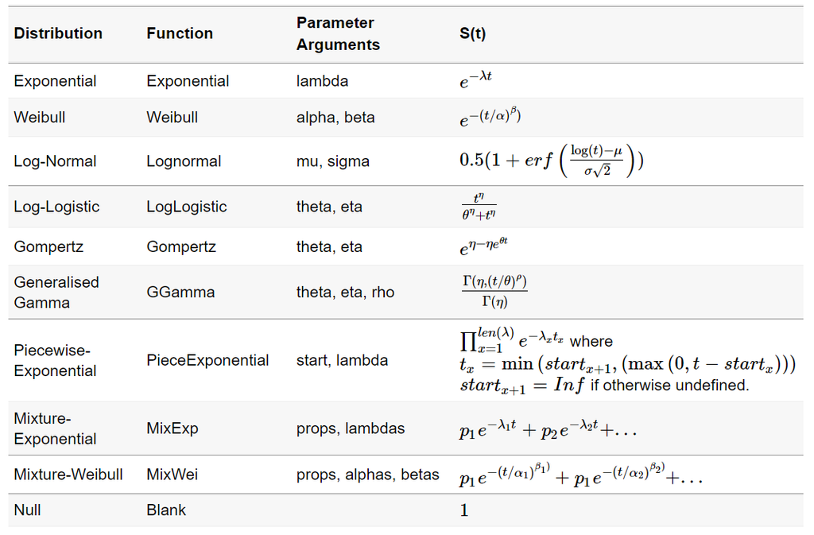

In `gestate` curves are created to represent the event and/or sensoring distributions. The above image illustrates the different types of distributions (and the associated functions) available in this package.

To create these curves, you use the various associated functions.

```r
# Creates a blank curve
curveNull <- Blank()
curveNull
```

```
## Curve Object
## Type: Blank
## Distribution Parameters:
##    Zero :  0
```

```r
  # Weibull - alpha = scale parameter,
  #           beta  = shape parameter
curveWeibull <- Weibull(alpha = 200, beta = .8)
curveWeibull
```

```
## Curve Object
## Type: Weibull
## Distribution Parameters:
##    scale :  200
##    shape :  0.8
```

```r
  # Lognormal - mu    = mean parameter
  #             sigma = standard deviation parameter
curveLogNormal <- Lognormal(mu = 5, sigma = 1.2)
curveLogNormal
```

```
## Curve Object
## Type: Lognormal
## Distribution Parameters:
##    meanlog :  5
##    sdlog :  1.2
```

```r
  # Generalized Gamma
  #             theta = scale parameter,
  #             beta  = shape parameter,
  #             rho   = family parameter
curveGGamma <- GGamma(theta = 20, eta = 2, rho = .7)
curveGGamma
```

```
## Curve Object
## Type: GGamma
## Distribution Parameters:
##    scale :  20
##    shape :  2
##    family :  0.7
```

When it comes to Recruitment distribution, you have the following options:

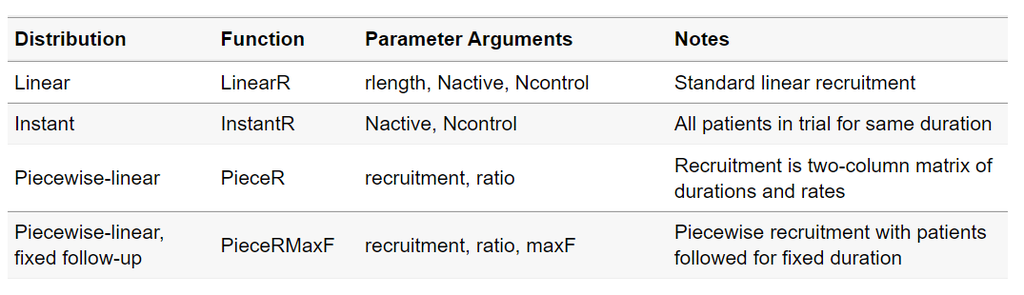

When it comes to recruitment, you have details of patient numbers for two arms; an active arm and a control arm. Secondly, it stores the distribution of patient recruitment, rather than a censoring distribution. This is because the ‘censoring distribution’ can only be defined in conjunction with an assessment time.

```r
#LinearR - Linear Recruitment Distribution
curveRecLinear <- LinearR(rlength  = 12,
                          Nactive  = 100,
                          Ncontrol = 100)
curveRecLinear
```

```
## RCurve Object
## Type: LinearR
## N Total: 200
## N Active: 100
## N Control: 100
## Recruitment Ratio: 1
## Distribution Parameters:
##    rlength :  12
```

```r
#InstantR - Instant Recruitment Distribution
curveRecInstant <- InstantR(Nactive  = 200,
                            Ncontrol = 250)
curveRecInstant
```

```
## RCurve Object
## Type: InstantR
## N Total: 450
## N Active: 200
## N Control: 250
## Recruitment Ratio: 0.8
## Distribution Parameters:
##    Dummy :  0
```

```r
#PieceRMaxF - Piecewise-Linear Recruitment Distribution
rec_matrix <- matrix(c(rep(4,3), 5, 10, 15),ncol=2)

curveRecPieceRMaxF <-
  PieceRMaxF(recruitment = rec_matrix,
             ratio = 1,
             maxF = 12)
curveRecPieceRMaxF
```

```
## RCurve Object
## Type: PieceR
## N Total: 120
## N Active: 60
## N Control: 60
## Recruitment Ratio: 1
## Distribution Parameters:
##    lengths :  4 4 4
##    rates :  5 10 15
##    maxF :  12
```

Now that we have the distributions, we can start to look at the key functions available through this package.

The main function we will start with is the `nph_traj` function, which calculates time-to-event trial properties for complex assumptions. The functions does power calculations, so it can be performed for sample size planning.

At a minimum, `nph_traj` requires a Curve object to describe the distribution of each of the active and control arms (‘active_ecurve’ and ‘control_ecurve’ arguments respectively), as well as an RCurve object (‘rcurve’ argument) to describe the recruitment distribution. The distributions of the active and control arms should typically be estimated based upon parameters or curve-fitting from previous trials (using e.g. fit_KM or fit_tte_data from the gestate package).

```r
  # Generalized Gamma
  #             theta = scale parameter,
  #             beta  = shape parameter,
  #             rho   = family parameter
# curveGGamma was created earlier
curveGGamma
```

```
## Curve Object
## Type: GGamma
## Distribution Parameters:
##    scale :  20
##    shape :  2
##    family :  0.7
```

```r
controlCurve <- curveGGamma
activeCurve <- curveGGamma <- GGamma(theta = 20*.7, eta = 2, rho = .7)

# Using the Piecewise-linear, fixed follow-up recruitment distribution
curveRecPieceRMaxF
```

```
## RCurve Object
## Type: PieceR
## N Total: 120
## N Active: 60
## N Control: 60
## Recruitment Ratio: 1
## Distribution Parameters:
##    lengths :  4 4 4
##    rates :  5 10 15
##    maxF :  12
```

```r
# Run nph_traj with default settings to calculate expected properties up to 10 months
# active_ecurve   - Event distribution for the active arm
# control_ecurve    - Event distribution for the control arm
# rcurve            - Recruitment distribution
# max_assessment    - Maximum assessment time to calculate properties up to
# CAN ALSO HAVE:
# control_dcurve  - Dropout/censoring distribution for the control arm
# active_dcurve   - Dropout/censoring distribution for the active arm
output <- nph_traj(active_ecurve=activeCurve,
                   control_ecurve=controlCurve,
                   rcurve=curveRecPieceRMaxF,
                   max_assessment=10)
output
```

```
## $active_ecurve
## Curve Object
## Type: GGamma
## Distribution Parameters:
##    scale :  14
##    shape :  2
##    family :  0.7
##
## $control_ecurve
## Curve Object
## Type: GGamma
## Distribution Parameters:
##    scale :  20
##    shape :  2
##    family :  0.7
##
## $active_dcurve
## Curve Object
## Type: Blank
## Distribution Parameters:
##    Zero :  0
##
## $control_dcurve
## Curve Object
## Type: Blank
## Distribution Parameters:
##    Zero :  0
##
## $rcurve
## RCurve Object
## Type: PieceR
## N Total: 120
## N Active: 60
## N Control: 60
## Recruitment Ratio: 1
## Distribution Parameters:
##    lengths :  4 4 4
##    rates :  5 10 15
##    maxF :  12
##
```

[output cut: 11 more lines]

```
## 7     7       50         1.167          0.754        1.921 1.5700 0.4511
## 8     8       60         1.650          1.072        2.722 1.5653 0.4481
## 9     9       75         2.246          1.466        3.712 1.5610 0.4453
## 10   10       90         2.979          1.953        4.933 1.5573 0.4430
##    LogHR_SE Schoenfeld_Power Frontier_Power
## 1  14.66570           0.0231         0.0250
## 2   6.52506           0.0210         0.0250
## 3   4.08628           0.0189         0.0250
## 4   2.94182           0.0170         0.0250
## 5   2.25815           0.0152         0.0250
## 6   1.79118           0.0133         0.0204
## 7   1.46492           0.0115         0.0159
## 8   1.23012           0.0099         0.0146
## 9   1.05296           0.0084         0.0133
## 10  0.91314           0.0071         0.0121
```

#### 2. Does the software model censoring?

Administrative censoring is handled implicitly based upon the specified RCurve object. However, dropout censoring is also common in time-to-event trials. This can be specified through Curve objects, and separate censoring distributions are supported for each arm. By default, gestate uses no censoring via the Blank() Curve.

It should be noted that the required censoring distributions must represent that of the censoring that would occur in the absence of events or administrative censoring. The observed numbers of censored patients in each arm will therefore also depend partially on the event distributions. The suggested way to use existing data to parameterise the censoring distributions is to create ‘reverse Kaplan Meier’ plots of existing data, whereby dropout censorings are ‘events’, and both events and administrative censorings are ‘censorings’.

```r
# Creating Active and Control censoring curves
censorCurveA <- Exponential(lambda=0.001)
censorCurveC <- Exponential(lambda=0.002)

output1 <- nph_traj(active_ecurve=activeCurve,
               control_ecurve=controlCurve,
               active_dcurve=censorCurveA,
               control_dcurve=censorCurveC,
               rcurve=curveRecPieceRMaxF,
               max_assessment=10,
               HRbound=1.3, # HR Value to test landmark significance against
               detailed_output = TRUE,
               required_power = 0.9)

output1
```

```
## $active_ecurve
## Curve Object
## Type: GGamma
## Distribution Parameters:
##    scale :  14
##    shape :  2
##    family :  0.7
##
## $control_ecurve
## Curve Object
## Type: GGamma
## Distribution Parameters:
##    scale :  20
##    shape :  2
##    family :  0.7
##
## $active_dcurve
## Curve Object
## Type: Exponential
## Distribution Parameters:
##    rate :  0.001
##
## $control_dcurve
## Curve Object
## Type: Exponential
## Distribution Parameters:
##    rate :  0.002
##
## $rcurve
## RCurve Object
## Type: PieceR
## N Total: 120
## N Active: 60
## N Control: 60
## Recruitment Ratio: 1
## Distribution Parameters:
##    lengths :  4 4 4
##    rates :  5 10 15
##    maxF :  12
##
```

[output cut: 33 more lines]

```
## 7      0.3073     0.6207        0.2126    0.479       0.479      1.5513
## 8      0.3635     0.6419        0.2993    0.678       0.678      1.5439
## 9      0.4220     0.6635        0.4056    0.924       0.924      1.5369
## 10     0.4839     0.6858        0.5360    1.227       1.227      1.5306
##    Schoenfeld_Power Event_Prop_Power Z_Power Frontier_Power Estimated_SS
## 1            0.0241           0.0241  0.0270         0.0256          Inf
## 2            0.0231           0.0232  0.0296         0.0265          Inf
## 3            0.0222           0.0222  0.0325         0.0274          Inf
## 4            0.0212           0.0213  0.0357         0.0284          Inf
## 5            0.0203           0.0204  0.0394         0.0294          Inf
## 6            0.0193           0.0194  0.0439         0.0253          Inf
## 7            0.0183           0.0184  0.0492         0.0208          Inf
## 8            0.0173           0.0175  0.0552         0.0201          Inf
## 9            0.0163           0.0165  0.0620         0.0194          Inf
## 10           0.0154           0.0156  0.0700         0.0188          Inf
```

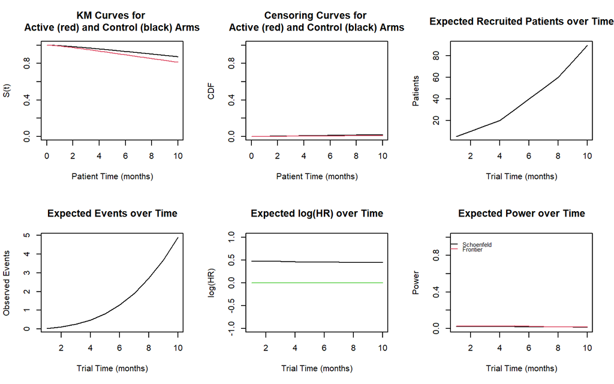

```r
activeCurveNPH <- Weibull(alpha=100,beta=0.8)
controlCurveNPH <-  Weibull(alpha=50,beta=1)

output2 <- nph_traj(active_ecurve=activeCurveNPH,
                    control_ecurve=controlCurveNPH,
                    rcurve=curveRecPieceRMaxF,
                    max_assessment=30,
                    RMST=20,
                    landmark=20)

plot_npht(output1)
```

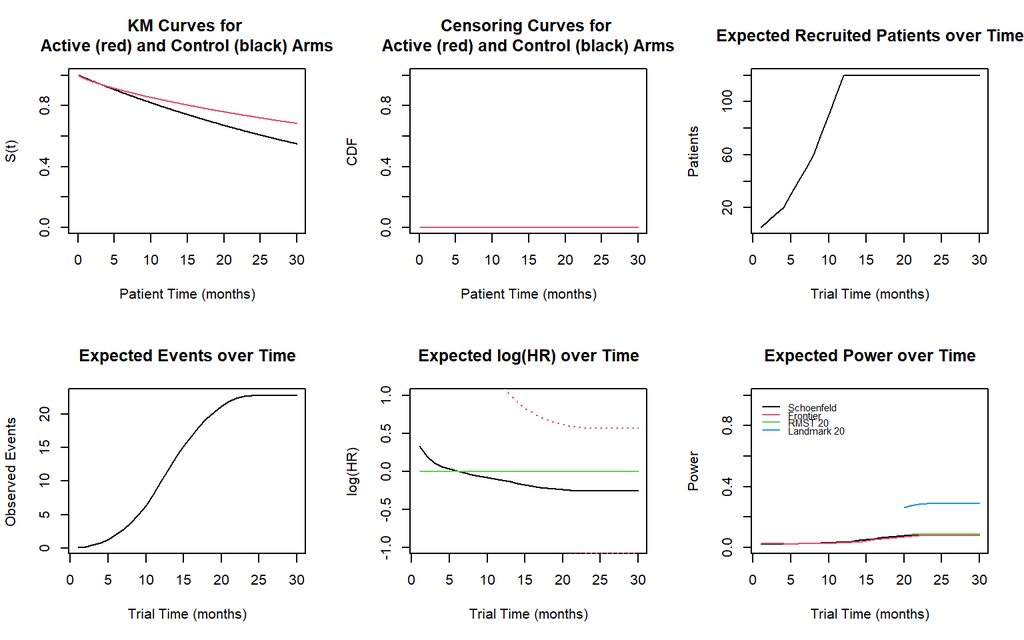

```r
plot_npht(output2)
```

#### 3. How should the data be organized as an input to the main function for each package?

```r
example_distribution <- Weibull(alpha=100,beta=0.8)
example_recruitment  <- LinearR(rlength=24,Nactive=600,Ncontrol=0)

# Create the full trajectory
maxtime <- 100
example_data_long <-
  simulate_trials(active_ecurve = example_distribution,
                  control_ecurve = example_distribution,
                  rcurve = example_recruitment,
                  assess=maxtime,
                  iterations=1,
                  seed=1234567,
                  detailed_output=TRUE)

# Shrink the trajectory to an early time point at which event prediction will occur
example_data_short <- set_assess_time(example_data_long,18)

head(example_data_short)
```

```
##           Time Censored Trt Iter      ETime CTime  Rec_Time Assess Max_F
## [1,]  9.027505        1   2    1  50.156774   Inf  8.972495     18   Inf
## [2,] 15.696356        1   2    1  24.022633   Inf  2.303644     18   Inf
## [3,]  2.643342        1   2    1   4.830987   Inf 15.356658     18   Inf
## [4,] 10.688501        1   2    1 481.597527   Inf  7.311499     18   Inf
## [5,]  5.759677        1   2    1  18.977798   Inf 12.240323     18   Inf
## [6,] 16.128620        1   2    1  67.922568   Inf  1.871380     18   Inf
##         RCTime
## [1,]  9.027505
## [2,] 15.696356
## [3,]  2.643342
## [4,] 10.688501
## [5,]  5.759677
## [6,] 16.128620
```

### Additional functionality

```r
fit2 <- fit_tte_data(data=example_data_short,Time="Time",Event="Censored",censoringOne=TRUE,type="automatic")
fit2
```

```
## $Curvetype
## [1] "Weibull"
##
## $Parameters
##      Alpha       Beta
## 74.9044606  0.8971022
##
## $VCov
##  Alpha_Var   Beta_Var Covariance
## 427.253348   0.010806  -1.827576
##
## $Fit
##      Distribution Metric           Value
## [1,] "Weibull"    "Log-Likelihood" "-300.998710542156"
## [2,] "Lognormal"  "Log-Likelihood" "-303.185871359364"
```

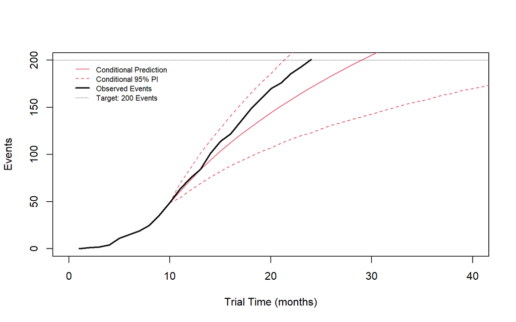

```r
# Create an RCurve incorporating both observed and predicted recruitment with arbitrary randomisation ratio of 1
recruit <- PieceR(matrix(c(rep(1,12),10,15,25,30,45,60,55,50,65,60,55,30),ncol=2),1)

trial_long <- simulate_trials(active_ecurve=Weibull(50,0.8),control_ecurve=Weibull(50,0.8),rcurve=recruit,fix_events=200,iterations=1,seed=12345,detailed_output=TRUE)
# Create a shortened version with data for use in the event prediction
trial_short <- set_assess_time(data=trial_long,time=10,detailed_output = FALSE)
# Create the trajectory of events
maxtime <- max(ceiling(trial_long[,"Assess"]))
events <- rep(NA,maxtime)
for (i in 1:maxtime){
  events[i] <- sum(1-set_assess_time(trial_long,i)[,"Censored"])
}
predictions <- event_prediction(data=trial_short, Event="Censored", censoringOne=TRUE, type="Weibull", rcurve=recruit,max_time=60, cond_Events=49, cond_NatRisk=451, cond_Time=10, units="Months")

# Plot observed events and conditional predictions
plot_ep(predictions,trajectory="conditional",which_PI="conditional",max_time=40,observed=events,target=200,max_E=200)
```

```r
trial_less_short <- set_assess_time(data=trial_long,time=14,detailed_output = FALSE)
predictions2 <- event_prediction(data=trial_less_short, Event="Censored",censoringOne=TRUE, type="Weibull", rcurve=recruit,max_time=60, cond_Events=101,cond_NatRisk=399,cond_Time=14, units="Months")

trial_mature <- set_assess_time(data=trial_long,time=18,detailed_output = FALSE)
predictions3 <- event_prediction(data=trial_mature, Event="Censored",censoringOne=TRUE, type="Weibull", rcurve=recruit,max_time=60, cond_Events=148,cond_NatRisk=352,cond_Time=18, units="Months")
```

# `eventTrack` example/vignette

The [eventTrack](https://cran.r-project.org/web/packages/eventTrack/index.html) uses a Hybrid framework with a KM-curve and an exponential tail. It tends to utilize this hybrid framework in conjunction with the `rpact` package

```r
#install.packages("eventTrack")
library(eventTrack)
 ls(asNamespace("eventTrack"))
```

```
##  [1] "bootstrapTimeToEvent"            "bootSurvivalSample"
##  [3] "exactDatesFromMonths"            "hybrid_Exponential"
##  [5] "kaplanMeier_at_t0"               "lambda_j_Exp"
##  [7] "piecewiseExp_MLE"                "piecewiseExp_profile_loglik_tau"
##  [9] "piecewiseExp_test_changepoint"   "predictEvents"
## [11] "predictEventsUncond"
```

```r
#install.packages(c("rpact", "fitdistrplus"))
library(rpact)          # to simulate illustrative dataset
library(fitdistrplus)   # to estimate Weibull fit
```

The next portion outlines how you predict an interim (IA) or final analysis (FA) clinical cutoff date (CCOD) in an ongoing trial, i.e. in a trial where

- patients have already been recruited but have not yet experienced the event and/or
- patients have already been recruited and have already experienced the event and/or
- further patients will be recruited in the future.

#### 2. Does the software model censoring?

Yes

#### 3. How should the data be organized as an input to the main function for each package?

In order to make event predictions, a sufficiently clean dataset including accrual times and the relevant time-to-event endpoint data up to the CCOD is needed. In addition, if recruitment is not yet completed, a prediction regarding the accrual of the remaining patient is required as well.

The `getDesignGroupSequential` function from the `rpact` package sets up the boundaries and defines a group sequential design.

```r
# ------------------------------------------------------------
# trial details
# ------------------------------------------------------------

alpha <- 0.05 #Significance Level for Design
beta <- 0.2   #Type II Error Rate

design <- getDesignGroupSequential(
  informationRates = 1,
  typeOfDesign = "asOF",
  sided = 1,
  alpha = alpha,
  beta = beta)
```

```r
# max number of patients
maxNumberOfSubjects1 <- 500
maxNumberOfSubjects2 <- 500
maxNumberOfSubjects <- maxNumberOfSubjects1 + maxNumberOfSubjects2

# survival hazard
piecewiseSurvivalTime <- c(0, 6, 9)
lambda2 <- c(0.025, 0.04, 0.02)

# effect size
hr <- 0.75

# quantities that determine timing of reporting events
dout1 <- 0
dout2 <- 0
douttime <- 12
accrualTime <- 0
accrualIntensity <- 42

# maximal sample size
samplesize <- getSampleSizeSurvival(
                design = design,
                piecewiseSurvivalTime = piecewiseSurvivalTime,
                lambda2 = lambda2,
                hazardRatio = hr,
                dropoutRate1 = dout1,
                dropoutRate2 = dout2,
                dropoutTime = douttime,
                accrualTime = accrualTime,
                accrualIntensity = accrualIntensity,
                maxNumberOfSubjects = maxNumberOfSubjects)

nevents <- as.vector(ceiling(samplesize$eventsPerStage))
```

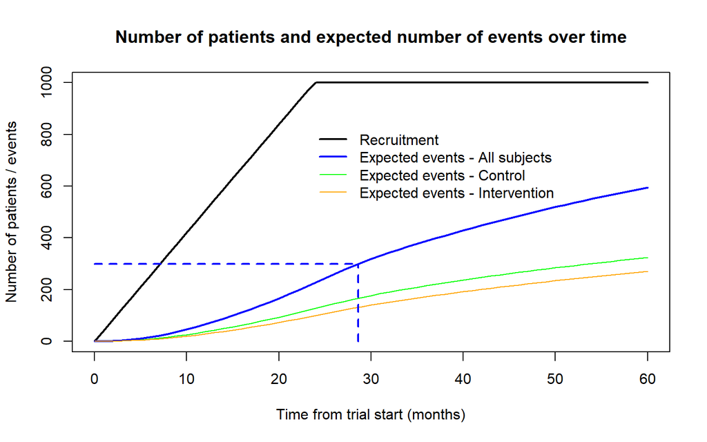

```r
# expected number of events overall and per group at 1-60 months after trial start
time <- 0:60
probEvent <- getEventProbabilities(time = time,
    piecewiseSurvivalTime = piecewiseSurvivalTime,
    lambda2 = lambda2,
    hazardRatio = hr,
    dropoutRate1 = dout1,
    dropoutRate2 = dout2,
    dropoutTime = douttime,
    accrualTime = accrualTime,
    accrualIntensity = accrualIntensity,
    maxNumberOfSubjects = maxNumberOfSubjects)

# extract expected number of events
expEvent <- probEvent$overallEventProbabilities * maxNumberOfSubjects   # overall
expEventInterv <- probEvent$eventProbabilities1 * maxNumberOfSubjects1  # intervention
expEventCtrl <- probEvent$eventProbabilities2 * maxNumberOfSubjects2   # control

# cumulative number of recruited patients over time
nSubjects <- getNumberOfSubjects(time = time,
                                 accrualTime = accrualTime,
                                 accrualIntensity = accrualIntensity,
                                 maxNumberOfSubjects = maxNumberOfSubjects)

# plot results
plot(time,
     nSubjects$numberOfSubjects,
     type = "l",
     lwd = 2,
     main = "Number of patients and expected number of events over time",
     xlab = "Time from trial start (months)",
     ylab = "Number of patients / events")
lines(time, expEvent, col = "blue", lwd = 2)
lines(time, expEventCtrl, col = "green")
lines(time, expEventInterv, col = "orange")
legend(x = 23, y = 850,
     legend = c("Recruitment", "Expected events - All subjects",
                "Expected events - Control", "Expected events - Intervention"),
       col = c("black", "blue", "green", "orange"), lty = 1, lwd = c(2, 2, 1, 1),
       bty = "n")

# add lines with event prediction pre-trial
fa_pred_pretrial <- exactDatesFromMonths(data.frame(1:length(expEvent) - 1, expEvent), nevents)
segments(fa_pred_pretrial, 0, fa_pred_pretrial, nevents, lwd = 2, lty = 2, col = "blue")
segments(0, nevents, fa_pred_pretrial, nevents, lwd = 2, lty = 2, col = "blue")
```

### SIMULATION

```r
seed <- 2020

# ------------------------------------------------------------
# generate a dataset with 1000 patients
# administratively censor after 100 events
# ------------------------------------------------------------

# number of events after which to administratively censor
nevents_admincens <- 100

# generate a dataset after the interim analysis, administratively censor after 100 events
trial1 <- getSimulationSurvival(design,
    piecewiseSurvivalTime = piecewiseSurvivalTime, lambda2 = lambda2,
    hazardRatio = hr, dropoutRate1 = dout1, dropoutRate2 = dout2, dropoutTime = douttime,
    accrualTime = accrualTime, accrualIntensity = accrualIntensity,
    plannedEvents = nevents_admincens, directionUpper = FALSE,
    maxNumberOfSubjects = maxNumberOfSubjects, maxNumberOfIterations = 1,
    maxNumberOfRawDatasetsPerStage = 1, seed = seed)
trial2 <- getRawData(trial1)


# clinical cutoff date for this analysis
ccod <- trial2$observationTime[1]

kable(head(trial2, 10)[, 3:ncol(trial2)], row.names = FALSE)
```

| subjectId | accrualTime | treatmentGroup | survivalTime | dropoutTime | observationTime | timeUnderObservation | event | dropoutEvent |
| --- | --- | --- | --- | --- | --- | --- | --- | --- |
| 1 | 0.0238095 | 1 | 64.9008011 | NA | 13.99707 | 13.9732632 | FALSE | FALSE |
| 2 | 0.0476190 | 2 | 20.5623950 | NA | 13.99707 | 13.9494536 | FALSE | FALSE |
| 3 | 0.0714286 | 1 | 59.7432789 | NA | 13.99707 | 13.9256441 | FALSE | FALSE |
| 4 | 0.0952381 | 2 | 27.8982841 | NA | 13.99707 | 13.9018346 | FALSE | FALSE |
| 5 | 0.1190476 | 1 | 7.1265000 | NA | 13.99707 | 7.1265000 | TRUE | FALSE |
| 6 | 0.1428571 | 2 | 2.7904861 | NA | 13.99707 | 2.7904861 | TRUE | FALSE |
| 7 | 0.1666667 | 1 | 6.8596179 | NA | 13.99707 | 6.8596179 | TRUE | FALSE |
| 8 | 0.1904762 | 2 | 20.4710395 | NA | 13.99707 | 13.8065965 | FALSE | FALSE |
| 9 | 0.2142857 | 1 | 0.1379221 | NA | 13.99707 | 0.1379221 | TRUE | FALSE |
| 10 | 0.2380952 | 2 | 43.9063079 | NA | 13.99707 | 13.7589774 | FALSE | FALSE |

Shape of the Data

```r
names(trial2)
```

```
##  [1] "iterationNumber"      "stopStage"            "subjectId"
##  [4] "accrualTime"          "treatmentGroup"       "survivalTime"
##  [7] "dropoutTime"          "observationTime"      "timeUnderObservation"
## [10] "event"                "dropoutEvent"
```

```r
head(trial2, n = 20)
```

```
##    iterationNumber stopStage subjectId accrualTime treatmentGroup survivalTime
## 1                1         1         1  0.02380952              1   64.9008011
## 2                1         1         2  0.04761905              2   20.5623950
## 3                1         1         3  0.07142857              1   59.7432789
## 4                1         1         4  0.09523810              2   27.8982841
## 5                1         1         5  0.11904762              1    7.1265000
## 6                1         1         6  0.14285714              2    2.7904861
## 7                1         1         7  0.16666667              1    6.8596179
## 8                1         1         8  0.19047619              2   20.4710395
## 9                1         1         9  0.21428571              1    0.1379221
## 10               1         1        10  0.23809524              2   43.9063079
## 11               1         1        11  0.26190476              1   91.8786217
## 12               1         1        12  0.28571429              2   63.5968235
## 13               1         1        13  0.30952381              1  112.1435137
## 14               1         1        14  0.33333333              2   22.9721798
```

[output cut: 27 more lines]

## Finishing it up

```r
pfsdata <- subset(trial2, subset = (timeUnderObservation > 0),
                  select = c("subjectId", "timeUnderObservation", "event"))
colnames(pfsdata) <- c("pat", "pfs", "event")
pfsdata[, "event"] <- as.numeric(pfsdata[, "event"])

# define variables with PFS time and censoring indicator
pfstime <- pfsdata[, "pfs"]
pfsevent <- pfsdata[, "event"]
```

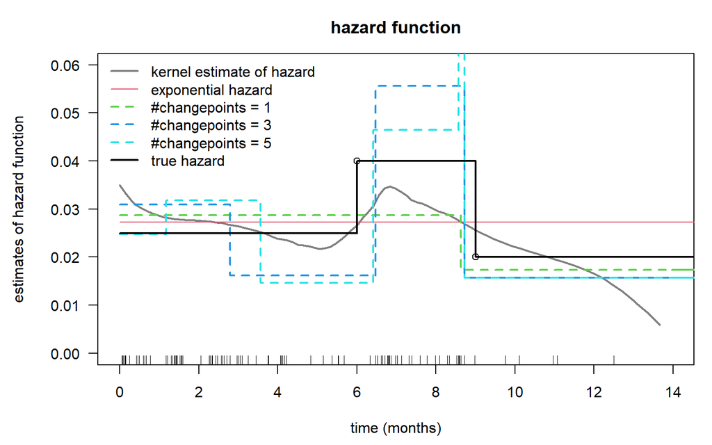

```r
# --------------------------------------------------
# analyze hazard functions
# --------------------------------------------------
oldpar <- par(las = 0, mar = c(5.1, 4.1, 4.1, 2.1))
par(las = 1, mar = c(4.5, 5.5, 3, 1))

# kernel estimate of hazard function
h.kernel1 <- muhaz(pfstime, pfsevent)
plot(h.kernel1, xlab = "time (months)", ylab = "", col = grey(0.5), lwd = 2,
     main = "hazard function", xlim = c(0, max(pfstime)), ylim = c(0, 0.06))
par(las = 3)
mtext("estimates of hazard function", side = 2, line = 4)
rug(pfstime[pfsevent == 1])

# MLE of exponential hazard, i.e. no changepoints
exp_lambda <- sum(pfsevent) / sum(pfstime)
segments(0, exp_lambda, 20, exp_lambda, lwd = 1, col = 2, lty = 1)

# add estimated piecewise exponential hazards
select <- c(1, 3, 5)
legend("topleft", legend = c("kernel estimate of hazard", "exponential hazard",
                             paste("#changepoints = ",
     select, sep = ""), "true hazard"), col = c(grey(0.5), 2, 3:(length(select) + 2), 1),
     lty = c(1, 1, rep(2, length(select)), 1), lwd = c(2, 1, rep(2, length(select)), 2),
     bty = "n")
for (i in 1:length(select)){
  pe1 <- piecewiseExp_MLE(pfstime, pfsevent, K = select[i])
  tau.i <- c(0, pe1$tau, max(pfstime))
  lambda.i <- c(pe1$lambda, tail(pe1$lambda, 1))
  lines(tau.i, lambda.i, type = "s", col = i + 2, lwd = 2, lty = 2)
  segments(max(tau.i), tail(lambda.i, 1), 10 * max(pfstime),
           tail(lambda.i, 1), col = i + 2, lwd = 2)
}

# since we simulated data we can add the truth
lines(stepfun(piecewiseSurvivalTime[-1], lambda2), lty = 1, col = 1, lwd = 2)
```

```r
# --------------------------------------------------
# starting from a piecewise Exponential hazard with
# K = 5 change points, infer the last "significant"
# change point
# --------------------------------------------------
pe5 <- piecewiseExp_MLE(time = pfstime, event = pfsevent, K = 5)
pe5.tab <- piecewiseExp_test_changepoint(peMLE = pe5, alpha = 0.05)
cp.select <- max(c(0, as.numeric(pe5.tab[, "established change point"])), na.rm = TRUE)
kable(subset(pe5.tab, select = c("k", "H_0", "alpha_{k-1}", "p-value", "reject",
                                 "established change point")), row.names = FALSE)
```

| k | H_0 | alpha_{k-1} | p-value | reject | established change point |
| --- | --- | --- | --- | --- | --- |
| 2 | lambda1 - lambda2 | 0.0250000 | 0.3913751 | 0 |  |
| 3 | lambda2 - lambda3 | 0.0125000 | 0.0098730 | 1 |  |
| 4 | lambda3 - lambda4 | 0.0062500 | 0.0023362 | 1 |  |
| 5 | lambda4 - lambda5 | 0.0031250 | 0.0943560 | 0 |  |
| 6 | lambda5 - lambda6 | 0.0015625 | 0.0408903 | 0 |  |

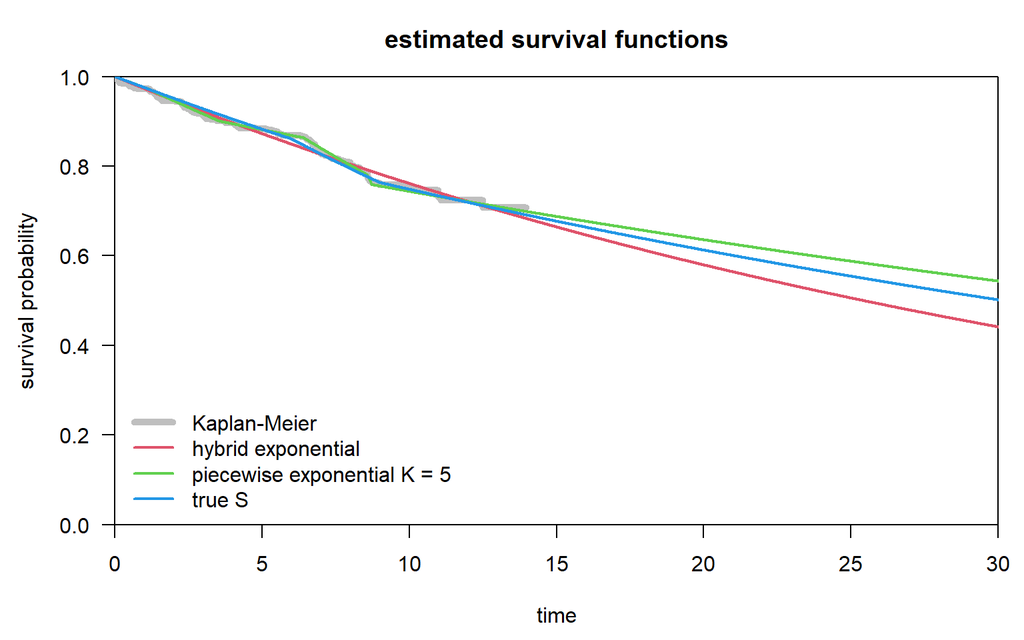

```r
# ------------------------------------------------------------
# projection for patients to be recruited after CCOD
# 42 patients / month, and we have maxNumberOfSubjects - length(pfstime)
# left to randomize. Assume they show up uniformly distributed
# this accrual is relative to the CCOD
# ------------------------------------------------------------
accrual_after_ccod <- 1:(maxNumberOfSubjects - length(pfstime)) / accrualIntensity

# Kaplan-Meier and hybrid Exponential tail fits, for different changepoints
par(las = 1, mar = c(4.5, 4.5, 3, 1))
plot(survfit(Surv(pfstime, pfsevent) ~ 1), mark = "", xlim = c(0, 30),
     ylim = c(0, 1), conf.int = FALSE, xaxs = "i", yaxs = "i",
     main = "estimated survival functions", xlab = "time",
     ylab = "survival probability", col = grey(0.75), lwd = 5)

# how far out should we predict monthly number of events?
future.units <- 15
tab <- matrix(NA, ncol = 2, nrow = future.units)
ts <- seq(0, 100, by = 0.01)

# the function predictEvents takes as an argument any survival function
# hybrid exponential with cp.select
St1 <- function(t0, time, event, cp){
     return(hybrid_Exponential(t0 = t0, time = time, event = event,
     changepoint = cp))}

pe1 <- predictEvents(time = pfstime, event = pfsevent,
          St = function(t0){St1(t0, time = pfstime,
          event = pfsevent, cp.select)}, accrual_after_ccod,
          future.units = future.units)
tab[, 1] <- pe1[, 2]
lines(ts, St1(ts, pfstime, pfsevent, cp.select), col = 2, lwd = 2)

# for illustration add piecewise exponential with five changepoints
St2 <- function(t0, time, event, tau, lambda){
      return(1 - getPiecewiseExponentialDistribution(time = t0,
                        piecewiseSurvivalTime = tau,
                        piecewiseLambda = lambda))}

pe2 <- predictEvents(time = pfstime, event = pfsevent,
          St = function(t0){St2(t0, time = pfstime,
          event = pfsevent, tau = c(0, pe5$tau),
          lambda = pe5$lambda)}, accrual_after_ccod,
          future.units = future.units)
tab[, 2] <- pe2[, 2]
lines(ts, St2(ts, pfstime, pfsevent, c(0, pe5$tau), pe5$lambda), col = 3, lwd = 2)

# since we have simulated data we can add the truth
tp <- seq(0, 100, by = 0.01)
lines(tp, 1 - getPiecewiseExponentialDistribution(time = tp,
                        piecewiseSurvivalTime = piecewiseSurvivalTime,
                        piecewiseLambda = lambda2), col = 4, lwd = 2, lty = 1)

# legend
legS <- c("Kaplan-Meier", "hybrid exponential",
          "piecewise exponential K = 5", "true S")
legend("bottomleft", legS, col = c(grey(0.75), 2:4),
       lwd = c(5, 2, 2, 2), bty = "n", lty = 1)
```

```r
tab <- data.frame(pe1[, 1], round(tab, 1))
colnames(tab) <- c("month", legS[2:3])
```

```r
kable(tab, row.names = FALSE)
```

| month | hybrid exponential | piecewise exponential K = 5 |
| --- | --- | --- |
| 1 | 113.7 | 112.8 |
| 2 | 128.1 | 125.8 |
| 3 | 143.2 | 139.5 |
| 4 | 159.1 | 153.8 |
| 5 | 175.7 | 168.5 |
| 6 | 193.0 | 183.5 |
| 7 | 210.9 | 198.8 |
| 8 | 229.5 | 214.6 |
| 9 | 248.7 | 230.9 |
| 10 | 268.5 | 247.6 |
| 11 | 288.2 | 264.0 |
| 12 | 307.3 | 279.6 |
| 13 | 326.0 | 294.4 |
| 14 | 344.1 | 308.5 |
| 15 | 361.8 | 322.3 |

```r
fa_pred_ccod <- exactDatesFromMonths(tab[, c("month", "hybrid exponential")], nevents)
fa_pred_ccod
```

```
## [1] 11.56545
```

```r
fa_pred_ccod + ccod
```

```
## [1] 25.56252
```

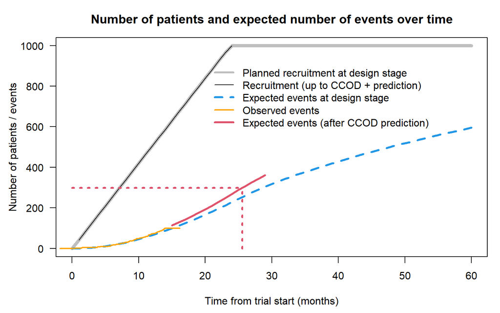

```r
# ------------------------------------------------------------
# plot event predictions pre-trial and after CCOD
# ------------------------------------------------------------
par(las = 1, mar = c(4.5, 4.5, 3, 1))
plot(time, nSubjects$numberOfSubjects, type = "l", lwd = 5, col = grey(0.75),
     main = "Number of patients and expected number of events over time",
     xlab = "Time from trial start (months)",
     ylab = "Number of patients / events")

# expected events at design stage
lines(time, expEvent, col = 4, lwd = 3, lty = 2)

# patients already recruited
tot_accrual1 <- subset(trial2, select = "accrualTime", subset = timeUnderObservation > 0)[, 1]

# add those that will only be recruited after CCOD
tot_accrual <- c(tot_accrual1, accrual_after_ccod + ccod)
tot_accrual_unit <- cumsum(table(cut(tot_accrual, 0:59, labels = FALSE)))

# actually not much to see, b/c simulated data perfectly uniform
lines(1:length(tot_accrual_unit), tot_accrual_unit, col = 1)

# now add event prediction based on hybrid exponential and 100 events
lines(tab$month + ccod, tab[, "hybrid exponential"], col = 2, lwd = 3)

# add lines with prediction based on CCOD data
segments(fa_pred_ccod + ccod, 0, fa_pred_ccod + ccod, nevents, lwd = 3, col = 2, lty = 3)
segments(0, nevents, fa_pred_ccod + ccod, nevents, lwd = 3, col = 2, lty = 3)

# finally, we add observed events over time
# note the x-axis of the plot (time from trial start), so we need to add accrual time
events_trial_time <- sort((pfstime + tot_accrual1)[pfsevent == 1])
lines(stepfun(events_trial_time, 0:sum(pfsevent)), pch = NA, col = "orange", lwd = 2)

# legend
legend(x = 20, y = 930, c("Planned recruitment at design stage",
                          "Recruitment (up to CCOD + prediction)",
                          "Expected events at design stage",
                          "Observed events",
                          "Expected events (after CCOD prediction)"),
       col = c(grey(0.75), 1, 4, "orange", 2), lty = c(1, 1, 2, 1, 1),
       lwd = c(3, 1, 3, 2, 3), bty = "n")
```

```r
# revert back to initial plot parameters
par(oldpar)
```

```r
# ------------------------------------------------------------
# compute a confidence interval for our event prediction using bootstrap
# ------------------------------------------------------------

# do not run as takes a few minutes, code only here for illustration
if (1 == 0){
boot1 <- bootstrapTimeToEvent(time = pfstime, event = pfsevent,
          interim.gates = nevents, future.units = 20, n = length(pfstime),
          M0 = 1000, K0 = 5, alpha = 0.05, accrual = accrual_after_ccod, seed = 2020)
ci <- quantile(boot1$event.dates[, 1], c(0.025, 0.975))
}

# hard-code result and add ccod
ci <- c(10.26989, 12.50578) + ccod
ci
```

```
## [1] 24.26696 26.50285
```

## Minimal Example

```r
pfsdata <- subset(trial2, subset = (timeUnderObservation > 0),
                  select = c("subjectId", "timeUnderObservation", "event"))
colnames(pfsdata) <- c("pat", "pfs", "event")
pfsdata[, "event"] <- as.numeric(pfsdata[, "event"])

# define variables with PFS time and censoring indicator
pfstime <- pfsdata[, "pfs"]
pfsevent <- pfsdata[, "event"]

# accrual after ccod
accrual_after_ccod <- 1:(maxNumberOfSubjects - length(pfstime)) / accrualIntensity

# infer changepoint
pe5 <- piecewiseExp_MLE(time = pfstime, event = pfsevent, K = 5)
pe5.tab <- piecewiseExp_test_changepoint(peMLE = pe5, alpha = 0.05)
cp.selected <- suppressWarnings(max(as.numeric(pe5.tab[, "established change point"]),
                                             na.rm = TRUE))
cp.selected <- max(cp.selected, 0)

# compute predictions for selected hybrid exponential model, i.e. chosen changepoint
future.units <- 15
St1 <- function(t0, time, event, cp){
     return(hybrid_Exponential(t0 = t0, time = time, event = event,
     changepoint = cp))}

pe1 <- predictEvents(time = pfstime, event = pfsevent,
          St = function(t0){St1(t0, time = pfstime,
          event = pfsevent, cp.selected)}, accrual_after_ccod,
          future.units = future.units)

# find exact timepoint when targeted number of events are reached through linear interpolation
# add computation of confidence interval using code from just above
fa_pred_ccod <- exactDatesFromMonths(tab[, c("month", "hybrid exponential")], nevents)

fa_pred_ccod + ccod
```

```
## [1] 25.56252
```

# `eventPrediction` example/vignette

The eventPrediction package is a package that was developed by scientific computing solutions and can be found on their github site. It is a package that has not had recent updates, but can be downloaded from GitHub and unzipped into your local directory.

The `eventPrediction` package uses methods to predict either the required number to achieve a target or the expected time at which you will reach the required number of events. You can use this package in the design phase of clinical trials or in the reporting phase. Which means you can use it to simulate a trial based on a set of assumptions and run predictions and calculate uncertainties when your trial will finish. Alternatively you can upload your trial data, simulate additional patient recruitment based on observed one and run prediction on when the target number of event will be reached or the expected number of events at a given time.

Installation of this package and it’s vignettes was not fully straightforward, but it can be done with a little extra work.

```r
#install.packages("~/R/win-library/4.1/eventPrediction-master.zip", repos = NULL, type = "win.binary")
library(eventPrediction)

# ls(asNamespace("eventPrediction"))
#remotes::install_github("RinteRface/fullPage")

# devtools::install_github("scientific-computing-solutions/eventPrediction",
#                         build_vignettes = TRUE, force = TRUE)
# load()
```

#### 1. What distributions are used to model time-to-event outcomes

To estimate time-to-event outcomes, the `eventPrediction` package uses Weibull and loglogistic models within the fit function from the `survreg` package.

#### 2. Does the software model censoring?

Yes. We can use `CensorInformation` function to check out what has been censored.

#### 3. How should the data be organized as an input to the main function for each package?

The data for input should be organized quite how you would normally organize data for survival analysis. An example can be seen below:

```r
data(event.data)

event.data %>%
  arrange(randDate) %>%
  head(n = 20)
```

```
##    subject site arm   randDate  eventDate time hasEvent   lastDate withdrawn
## 1      402    5   1 2014-01-01 2014-02-14   45        1 2014-02-14         0
## 2      401    5   1 2014-01-01 2014-04-16  106        1 2014-04-16         0
## 3      301    4   1 2014-01-01 2014-06-11  162        1 2014-06-11         0
## 4      701    8   1 2014-01-01 2015-01-24  389        1 2015-01-24         0
## 5      601    7   1 2014-01-02       <NA>  696        0 2015-11-28         0
## 6      801    9   1 2014-01-02       <NA>  696        0 2015-11-28         0
## 7      602    7   1 2014-01-05 2014-05-22  138        1 2014-05-22         0
## 8      901   10   1 2014-01-05 2014-09-18  257        1 2014-09-18         0
## 9      201    3   1 2014-01-06 2015-03-09  428        1 2015-03-09         0
## 10     702    8   1 2014-01-06 2015-08-20  592        1 2015-08-20         0
## 11     202    3   1 2014-01-08       <NA>  690        0 2015-11-28         0
## 12     203    3   1 2014-01-09 2014-02-16   39        1 2014-02-16         0
## 13     403    5   1 2014-01-09 2014-04-23  105        1 2014-04-23         0
## 14     404    5   1 2014-01-09 2015-02-28  416        1 2015-02-28         0
```

[output cut: 27 more lines]

```r
names(event.data)
```

```
##  [1] "subject"   "site"      "arm"       "randDate"  "eventDate" "time"
##  [7] "hasEvent"  "lastDate"  "withdrawn" "eventType"
```

One issue that may arise, comes with dates. The following three date formats are recognized by the package: `YYYY-MM-DD`, `DD/MM/YYYY` and `DD Month YYYY`. You may have to do some date manipulation if your dates are not in the correct format.

To get started, we have to create an event data object. To do this, you utilize the `EventData` function, which is a constructor for an event data object.

```r
#?EventData
my.data <- EventData(data=event.data,
                     subject="subject",
                     rand.date="randDate",
                     has.event="hasEvent",
                     withdrawn="withdrawn",
                     time="time",
                     site="site", #optional
                     event.type="eventType") #optional
```

`EventData` function arguments:

- data = Dataset with parameters
- subject = Subject ID
- rand.date = Data of randomization onto trial
- has.event = Had an event or not
- withdrawn = Withdrawn or not
- time = days on trial until event
- site = Center/hospital/location, etc
- event.type = Type of Event that occurred

```r
summary(my.data)
```

```
## Number of subjects: 979
## Number of events: 699
##  Of type Event type 1: 358
##  Of type Event type 2: 341
## Number of withdrawn: 0
## First subject randomized: 2014-01-01
## Last subject randomized: 2015-11-26
## First Event: 2014-01-19
## Last Event: 2015-11-27
## Average recruitment (subjects/day): 1.41
```

```r
# CalculateDaysAtRisk Function will calculate number of subject years at risk
CalculateDaysAtRisk(my.data)
```

```
## [1] 176319
```

```r
CalculateDaysAtRisk(my.data)/365.25
```

```
## [1] 482.7351
```

Plotting number of events over time is also done utilizing the `EventVsTimePlot` function.

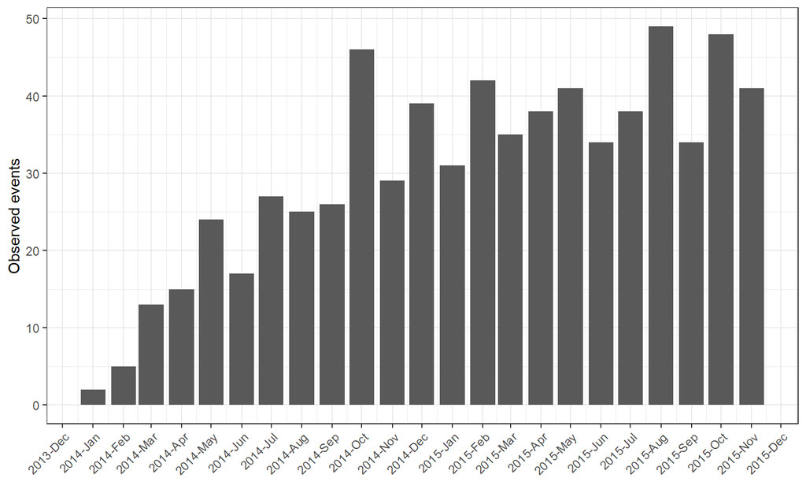

```r
EventVsTimePlot(my.data)
```

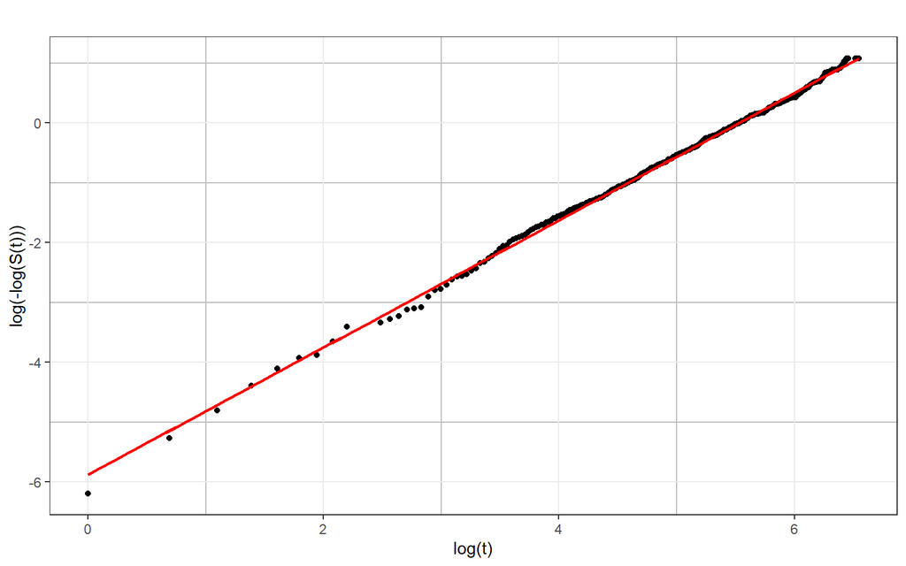

```r
plot(my.data)
```

### Censoring

To Extracting subjects censored before a given date.

```r
censor.df <- censorInformation(my.data,censor.date="2015-12-31")
head(censor.df)
```

```
##   subject timelag  rand.date time
## 1     313     129 2014-04-12  500
## 2     344      54 2014-09-27  407
## 3     298      48 2015-09-30   45
## 4     794      44 2015-08-31   79
## 5     687      34 2015-09-06   83
## 6     888      34 2015-09-19   70
```

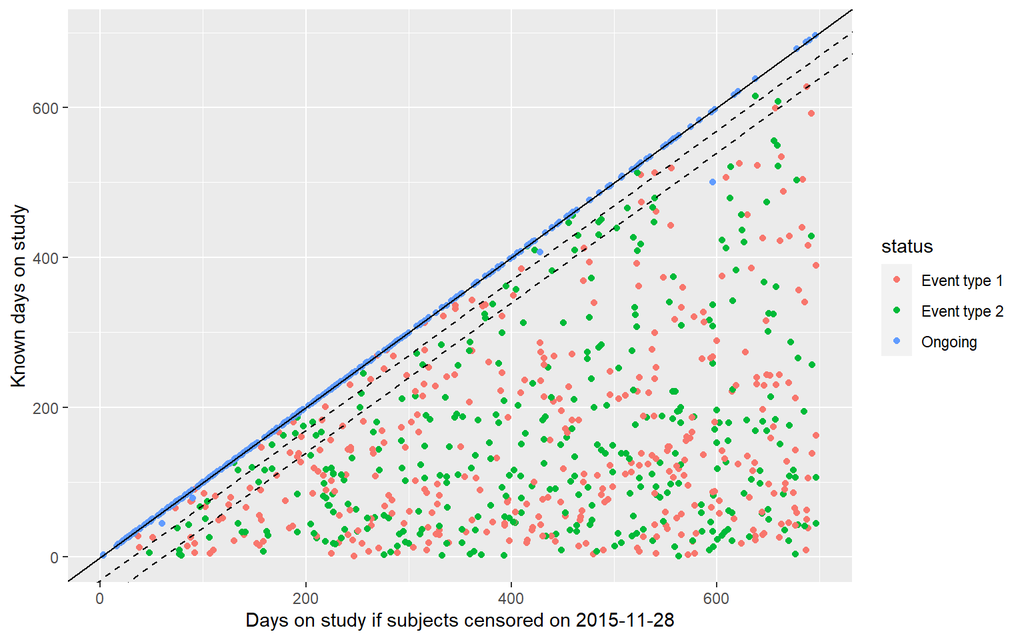

```r
# We can visualize this lag between the date of the
# analysis and the time subjects are censored:
DiagnosticPlot(my.data,window.size=30,separate.events=TRUE)
```

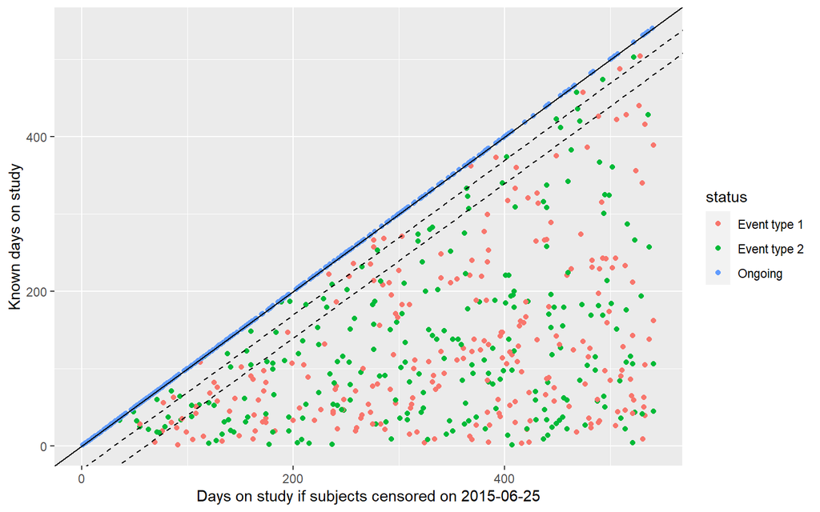

```r
#?CutData
# YOu can use the CutData function to provide
# a specific cutoff point.
DiagnosticPlot(
  CutData(my.data, "25/6/2015"),
  window.size=30,
  separate.events=TRUE)
```

### Fitting a model and Event Prediction

The simulate procedure is used to generate when events are expected to occur. This function uses the parameters of a fitted Weibull model (or loglogistic) to simulate the time-to-event for all subjects who have not had an event. Conditional Weibull distributions (or loglogistic) are used to take into account the time since randomization for each subject.

```r
my.fit <- fit(my.data)
my.fit
```

```
## Call:
## survreg(formula = Surv(time, has.event) ~ 1, data = indat, dist = dist,
##     y = TRUE)
##
## Coefficients:
## (Intercept)
##    5.530591
##
## Scale= 0.9391685
##
## Loglik(model)= -4562.7   Loglik(intercept only)= -4562.7
## n= 979
```

We then can take the model and run simulations on the data. This is a simple version of the simulation, but you can add things like number of additional individuals accrued and who have dropped out.

```r
results <- simulate(my.fit,
Nsim=500, #Number of simulations to perform
seed = 20141015) #A random seed for reproducibility

summary(results)
```

```
## 979 patients recruited where last patient in on 2015-11-26
## and last event observed at 2015-11-27 (699 events). Using
## weibull survival model.
```

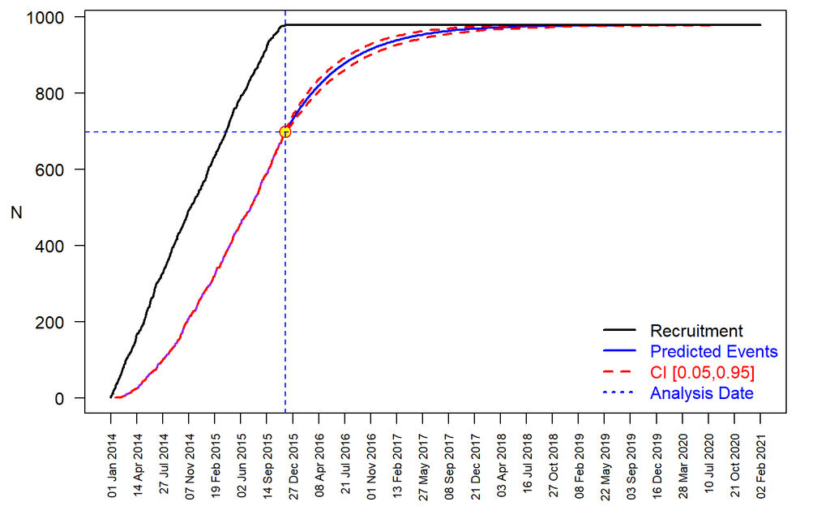

```r
plot(results)
```

```r
my.fit2 <- fit(my.data, dist = "loglogistic" )
my.fit2
```

```
## Call:
## survreg(formula = Surv(time, has.event) ~ 1, data = indat, dist = dist,
##     y = TRUE)
##
## Coefficients:
## (Intercept)
##    5.111549
##
## Scale= 0.7165658
##
## Loglik(model)= -4579.2   Loglik(intercept only)= -4579.2
## n= 979
```

```r
results2 <- simulate(my.fit2,
Nsim=500, #Number of simulations to perform
seed = 20141015) #A random seed for reproducibility

summary(results2)
```

```
## 979 patients recruited where last patient in on 2015-11-26
## and last event observed at 2015-11-27 (699 events). Using
## loglogistic survival model.
```

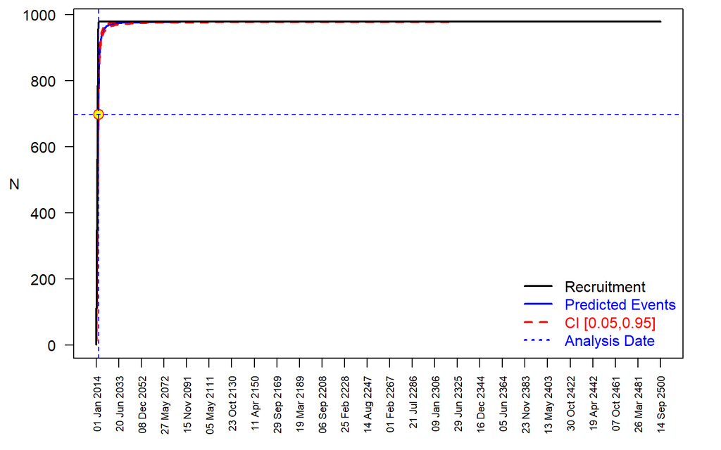

```r
plot(results2)
```

### Predictions

You can then feed in the results of the simulation into the `predict` function. Here, we can choose the predicted time for a number of events given by the `event.pred` argument. The `event.pred` argument can take a vector of values to check multiple predictions.

```r
#?predict
results <- predict(results,
                   event.pred=c(700, 800, 900 ))
summary(results)
```

```
## 979 patients recruited where last patient in on 2015-11-26
## and last event observed at 2015-11-27 (699 events). Using
## weibull survival model. The time at which 700 events have
## occurred is predicted to be 2015-11-27 [2015-11-27,
## 2015-11-29] with an expected 482.68 years of subjects at
## risk at this time. The time at which 800 events have
## occurred is predicted to be 2016-03-11 [2016-02-23,
## 2016-04-01] with an expected 547.78 years of subjects at
## risk at this time. The time at which 900 events have
## occurred is predicted to be 2016-09-13 [2016-08-04,
## 2016-10-29] with an expected 610.3 years of subjects at
## risk at this time.
```

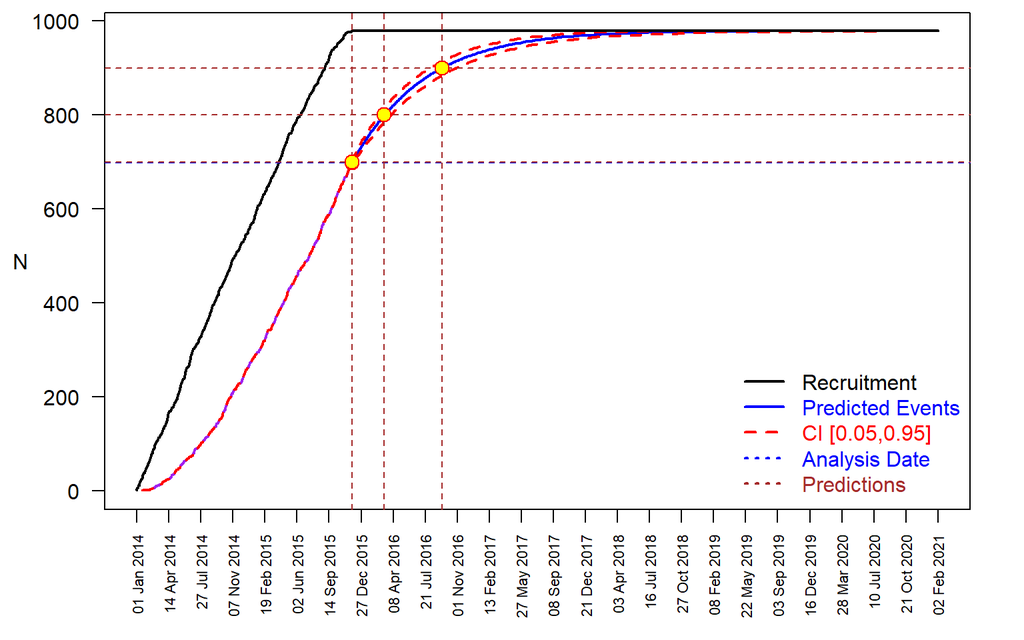

```r
plot(results)
```

```r
results <- predict(results,
                   event.pred=950,
                   time.pred=c("2017-10-10","2017-12-12"))
#Does not output the number of years at risk in this summary
summary(results,
        round.method="toMonths",
        show.at.risk=FALSE)
```

```
## 979 patients recruited where last patient in on 2015-11-26
## and last event observed at 2015-11-27 (699 events). Using
## weibull survival model. The time at which 700 events have
## occurred is predicted to be Nov 2015 [Nov 2015, Dec 2015].
## The time at which 800 events have occurred is predicted to
## be Mar 2016 [Feb 2016, Apr 2016]. The time at which 900
## events have occurred is predicted to be Sep 2016 [Jul 2016,
## Nov 2016]. The time at which 950 events have occurred is
## predicted to be Apr 2017 [Jan 2017, Jul 2017]. On
## 2017-10-10 the predicted number of events is 966 [958,
## 972]. On 2017-12-12 the predicted number of events is 969
## [962, 975].
```

```r
#?predict
#These provide results for the multiple simulations at a time.
#The time.pred shows the results at given times,
#event.pred shows the results at a given event count
results@event.pred.data
```

```
##         time event     CI_low    CI_high daysatrisk
## 1 2015-11-27   700 2015-11-27 2015-11-29     176299
## 2 2016-03-11   800 2016-02-23 2016-04-01     200077
## 3 2016-09-13   900 2016-08-04 2016-10-29     222913
## 4 2017-04-22   950 2017-02-07 2017-07-08     234148
```

```r
results@time.pred.data
```

```
##         time event CI_low CI_high daysatrisk
## 1 2017-10-10   966    958     972   237749.5
## 2 2017-12-12   969    962     975   238503.0
```

# Comparisons Between the 3 Packages

#### 2. Does the software model censoring?

Yes for all three

#### 3. Shape of the data.

See vignettes.

#### 4. Which package was easiest to understand?

`gestate` has a very nice vignette and documentation. It was easy to install and get started with. It is also available on the CRAN, which makes it easy to download. It appears to be the most fully featured and the most up to date of the three packages.

The `eventTrack` package was easy to install and did not have a lot of extra functions. It was built to be used on top of other mature packages, which makes it a bit more stable. I did find it to be the most unwieldy and it required a lot of inputs for the various functions. EventTrack does not appear to handle drop outs, like `gestate`.

Tricky to install and get `eventPrediction` started, since it is not updated to more recent standards and is only available through GitHub. However, it is pretty straightforward once you get everything installed.